# Cluster Analysis - H1B Data

Ashita Shetty

```r
library(readr)
h1b <- read_csv("C:\\Users\\Dell\\Desktop\\RBS\\Semester II\\Multivariate Analysis\\Assignment\\data\\H1_B-2014-K.csv")
#Loading the libraries

library(cluster)
library(readr)
library(factoextra)
library(magrittr)
library(NbClust)
```

#### **1. For each model, decide the optimal number of clusters and explain why.**

```r
h1b$WAGE_RATE_FROM <- as.numeric(h1b$LCA_CASE_WAGE_RATE_FROM)
h1b$EMPLOYER_POSTAL_CODE <- as.numeric(h1b$LCA_CASE_EMPLOYER_POSTAL_CODE)
h1b$EMP_DIFF <- as.numeric(h1b$EMP_DIFF)
h1b$APP_DIFF <- as.numeric(h1b$APP_DIFF)
h1b$TOTAL_WORKERS <- as.numeric(h1b$TOTAL_WORKERS)
h1b$YR_SOURCE <- as.numeric(h1b$YR_SOURCE_PUB_1)
h1b$NAICS_CODE <- as.numeric(h1b$LCA_CASE_NAICS_CODE)
```

##### **Scaling the H1B data**

```r
matstd.h1b <- scale(h1b[, c( "WAGE_RATE_FROM", "EMPLOYER_POSTAL_CODE", "APP_DIFF", "EMP_DIFF", "TOTAL_WORKERS")])
rownames(matstd.h1b) <- h1b$LCA_CASE_JOB_TITLE
```

```r
matstd.h1b
```

```
##                                                WAGE_RATE_FROM
## CHIEF EXECUTIVE                                   0.628064432
## INFORMATICA DEVELOPER                            -0.474219425
## SOFTWARE DEVELOPER                               -0.441064757
## PROGRAMMER ANALYST                               -0.246677631
## SENIOR RESEARCH DATA COORDINATOR                  0.194767172
## SENIOR PRODUCT MANAGER                            0.919645120
## USER EXPERIENCE DESIGNER                         -0.693768019
## COMPUTER PROGRAMMER / ANALYST                    -0.538258319
## LEAD DEVELOPMENT COORDINATOR                     -0.084150556
## ASSISTANT VICE PRESIDENT                         -0.154343747
## MANAGER, ENTERPRISE SOLUTION DELIVERY             1.297280988
## PROJECT MANAGER - III                             0.008552664
## FUNCTIONAL ANALYST                               -0.199791457
## MDM DEVELOPER                                    -0.427321587
## TB/HIV PROJECT DIRECTOR                          -0.003693725
## FINANCIAL MANAGER, HEAD OF TRADING                0.044903057
## CONSULTANT                                       -0.373029263
## RESEARCH ASSISTANT PROFESSOR                     -1.703771059
## MODULE LEAD                                      -0.392467975
## SOFTWARE DEVELOPMENT ENGINEER III                 1.308419371
## ART DIRECTOR                                      0.239290182
## RESTRUCTURING MANAGER                             1.178179997
## ACCOUNT EXECUTIVE                                -1.043664845
## VICE PRESIDENT, TECHNICAL MARKETING               2.183161434
## QUALITY CONTROL SUPERVISOR                       -1.059682344
## MANAGER                                           0.744696707
## ASSOCIATE PROFESSOR                               0.500293775
## FUND ACCOUNTANT                                  -0.168922781
## SENIOR CONSULTANT                                -0.352113208
## COMMUNICATIONS SPECIALIST                        -1.704216789
## DEVICES DESIGN ENGINEER 3                         0.628064432
## SENIOR STRUCTURAL ENGINEER                        0.364747632
## SENIOR SOFTWARE ENGINEER                          0.603707726
## PRESCHOOL TEACHER                                -1.704231174
## METALLURGIST                                     -0.316656996
## ENGINEER, PRINCIPAL - IC DESIGN                   1.211225808
## PROCESS ENGINEER                                 -0.494132442
## BUSINESS EXCELLENCE MANAGER                       0.433677307
## PROJECT DEVELOPER                                -1.703928513
```

[output cut: 108 more lines]

```
## ACCOUNTANT                                      0.9065714    -0.2476821
## TOOLS DEVELOPER                                -1.0655457    -0.2476821
## SENIOR ASSOCIATE MARKETING STRATEGY & ANALYSIS  0.9033437    -0.2476821
## TECHNICAL SOLUTIONS ENGINEER                    0.9033437    -0.2476821
## SENIOR CREDIT TRADER                           -0.4060216    -0.2476821
## attr(,"scaled:center")
##       WAGE_RATE_FROM EMPLOYER_POSTAL_CODE             APP_DIFF
##           87690.0190           45500.8800               1.2562
##             EMP_DIFF        TOTAL_WORKERS
##              28.1038               2.0400
## attr(,"scaled:scale")
##       WAGE_RATE_FROM EMPLOYER_POSTAL_CODE             APP_DIFF
##         51443.736242         36584.385452             3.629310
##             EMP_DIFF        TOTAL_WORKERS
##             9.294580             4.198931
```

```r
dist.h1b <- dist(matstd.h1b, method = "euclidean")
clush1b.nn <- hclust(dist.h1b, method = "single")
```

##### **To find the Optimal Number of Clusters - Elbow Plot**

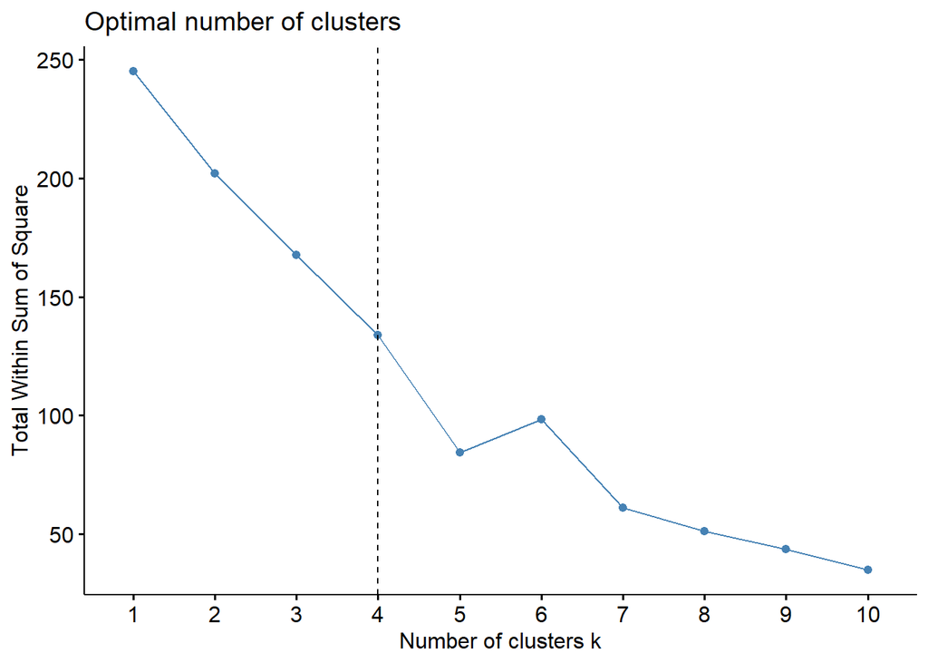

```r
fviz_nbclust(matstd.h1b, kmeans, method = "wss")+geom_vline(xintercept = 4, linetype = 2)
```

##### **Dendogram**

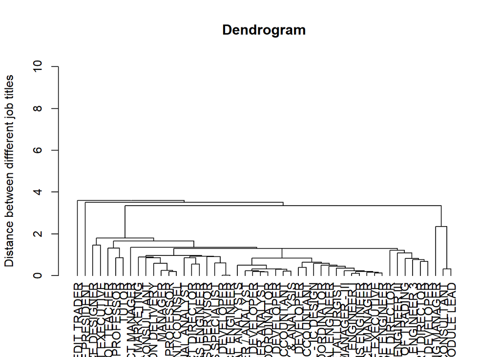

```r
plot(as.dendrogram(clush1b.nn),ylab="Distance between diffferent job titles",ylim=c(0,10),
     main="Dendrogram")
```

##### **Inference:**

- The Dendogram demonstrates the different clusters that can be formed based on the Profession of individuals who have applied for Visa. These clusters are being formed based on the multiple numerical columns that potentially contribute.

#### **2. Show the membership for each cluster**

##### **Clustering Analysis**

```r
set.seed(123)
kmeans4.h1b <- kmeans(matstd.h1b, 4, nstart = 25)

kmeans4.h1b
```

```
## K-means clustering with 4 clusters of sizes 2, 3, 24, 21
##
## Cluster means:
##   WAGE_RATE_FROM EMPLOYER_POSTAL_CODE   APP_DIFF   EMP_DIFF TOTAL_WORKERS
## 1      1.5003767           -0.9700144  4.2442775 -0.4076354    -0.2476821
## 2      0.1375609           -0.8312986 -0.2946933  0.4679645     3.8803528
## 3     -0.2910073           -0.7584806 -0.1205325 -0.2154087    -0.2476821
## 4      0.1700352            1.0779742 -0.2243664  0.2181517    -0.2476821
##
## Clustering vector:
##                                CHIEF EXECUTIVE
##                                              4
##                          INFORMATICA DEVELOPER
##                                              3
##                             SOFTWARE DEVELOPER
##                                              4
##                             PROGRAMMER ANALYST
##                                              3
##               SENIOR RESEARCH DATA COORDINATOR
##                                              4
##                         SENIOR PRODUCT MANAGER
##                                              4
##                       USER EXPERIENCE DESIGNER
##                                              3
##                  COMPUTER PROGRAMMER / ANALYST
##                                              3
##                   LEAD DEVELOPMENT COORDINATOR
##                                              3
##                       ASSISTANT VICE PRESIDENT
##                                              1
##          MANAGER, ENTERPRISE SOLUTION DELIVERY
##                                              3
##                          PROJECT MANAGER - III
##                                              4
##                             FUNCTIONAL ANALYST
##                                              3
##                                  MDM DEVELOPER
##                                              3
##                        TB/HIV PROJECT DIRECTOR
##                                              3
```

[output cut: 64 more lines]

```
## SENIOR ASSOCIATE MARKETING STRATEGY & ANALYSIS
##                                              3
##                   TECHNICAL SOLUTIONS ENGINEER
##                                              4
##                           SENIOR CREDIT TRADER
##                                              1
##
## Within cluster sum of squares by cluster:
## [1]  7.750274  3.788109 58.438442 36.808744
##  (between_SS / total_SS =  56.4 %)
##
## Available components:
##
## [1] "cluster"      "centers"      "totss"        "withinss"     "tot.withinss"
## [6] "betweenss"    "size"         "iter"         "ifault"
```

```r
clus1 <- matrix(names(kmeans4.h1b$cluster[kmeans4.h1b$cluster == 1]),
                ncol=1, nrow=length(kmeans4.h1b$cluster[kmeans4.h1b$cluster == 1]))
colnames(clus1) <- "Cluster 1"

clus2 <- matrix(names(kmeans4.h1b$cluster[kmeans4.h1b$cluster == 2]),
                ncol=1, nrow=length(kmeans4.h1b$cluster[kmeans4.h1b$cluster == 2]))
colnames(clus2) <- "Cluster 2"

clus3 <- matrix(names(kmeans4.h1b$cluster[kmeans4.h1b$cluster == 3]),
                ncol=1, nrow=length(kmeans4.h1b$cluster[kmeans4.h1b$cluster == 3]))
colnames(clus3) <- "Cluster 3"

clus4 <- matrix(names(kmeans4.h1b$cluster[kmeans4.h1b$cluster == 4]),
                ncol=1, nrow=length(kmeans4.h1b$cluster[kmeans4.h1b$cluster == 4]))
colnames(clus4) <- "Cluster 4"

list(clus1,clus2, clus3, clus4)
```

```
## [[1]]
##      Cluster 1
## [1,] "ASSISTANT VICE PRESIDENT"
## [2,] "SENIOR CREDIT TRADER"
##
## [[2]]
##      Cluster 2
## [1,] "CONSULTANT"
## [2,] "MODULE LEAD"
## [3,] "RESTRUCTURING MANAGER"
##
## [[3]]
##       Cluster 3
##  [1,] "INFORMATICA DEVELOPER"
##  [2,] "PROGRAMMER ANALYST"
```

[output cut: 46 more lines]

##### **Inference:**

- Based on the results derived from the Elbow Plot, we have created 4 Clusters.
- The output signifies the different clusters that have multiple professions clubbed together based on the multiple factors.

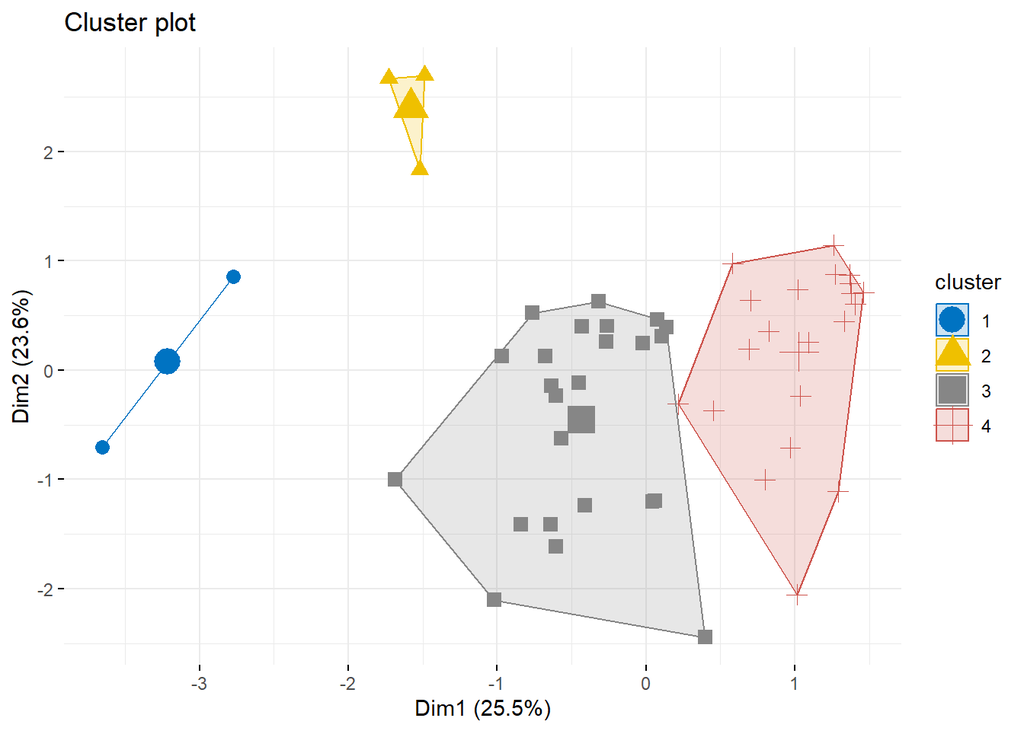

```r
km.res <- kmeans(matstd.h1b, 4, nstart = 25)
# Visualize
fviz_cluster(km.res, data = matstd.h1b,
             pca = FALSE,
             ellipse.type = "convex",
             palette = "jco",
             ggtheme = theme_minimal(),
             geom = "point",
             pointsize = 3,
             show.clust.cent = TRUE,
             repel = TRUE)
```

*The names of the job titles have been not displayed to avoid extreme clutter.*

##### **Inference:**

- Based on the output of different clusters with the professions in each, it can be observed how the different clusters have been formed.
- It can be observed that Clusters 3, and 4 are the most populated, whereas Cluster 1 can be observed to be the least with just a line.

#### **3. Show a visualization of the cluster and membership using the first two Principal Components**

##### **Conducting PCA on the scaled data of H1B**

```r
pca_h1b <- prcomp(matstd.h1b, scale = TRUE)
pca_h1b
```

```
## Standard deviations (1, .., p=5):
## [1] 1.1302069 1.0872533 1.0757060 0.8883623 0.7708319
##
## Rotation (n x k) = (5 x 5):
##                              PC1         PC2         PC3         PC4        PC5
## WAGE_RATE_FROM       -0.09178126  0.45252158  0.60672553  0.60945757 -0.2173615
## EMPLOYER_POSTAL_CODE  0.73557849  0.05267525  0.24587689  0.05051034  0.6270111
## APP_DIFF             -0.55527285 -0.03076008  0.53323999 -0.42086822  0.4788016
## EMP_DIFF              0.20926083  0.71836646  0.01393117 -0.60926394 -0.2622268
## TOTAL_WORKERS        -0.31365976  0.52483615 -0.53562088  0.27870696  0.5114658
```

```r
summary(pca_h1b)
```

```
## Importance of components:
##                           PC1    PC2    PC3    PC4    PC5
## Standard deviation     1.1302 1.0873 1.0757 0.8884 0.7708
## Proportion of Variance 0.2555 0.2364 0.2314 0.1578 0.1188
## Cumulative Proportion  0.2555 0.4919 0.7233 0.8812 1.0000
```

- The **cumulative variance** if first two Principal Components are considered is **0.49**.

```r
pca_h1b$x
```

```
##                                                        PC1        PC2
## CHIEF EXECUTIVE                                 1.27198095  0.8766718
## INFORMATICA DEVELOPER                          -0.26700552  0.2604120
## SOFTWARE DEVELOPER                              0.82454626  0.3558965
## PROGRAMMER ANALYST                              0.13665224  0.3938309
## SENIOR RESEARCH DATA COORDINATOR                0.70019286  0.6368263
## SENIOR PRODUCT MANAGER                          0.58161718  0.9753249
## USER EXPERIENCE DESIGNER                       -0.96760892  0.1277685
## COMPUTER PROGRAMMER / ANALYST                  -0.02287460  0.2483208
## LEAD DEVELOPMENT COORDINATOR                    0.07678127  0.4641091
## ASSISTANT VICE PRESIDENT                       -3.65630834 -0.7082897
## MANAGER, ENTERPRISE SOLUTION DELIVERY          -0.67878790  0.1262536
## PROJECT MANAGER - III                           1.40591193  0.6017989
## FUNCTIONAL ANALYST                             -1.02047419 -2.1042894
## MDM DEVELOPER                                   0.10827793  0.3088168
## TB/HIV PROJECT DIRECTOR                        -0.84113785 -1.4088232
## FINANCIAL MANAGER, HEAD OF TRADING              0.45237633 -0.3707294
## CONSULTANT                                     -1.48836322  2.6981761
## RESEARCH ASSISTANT PROFESSOR                    0.39669673 -2.4435902
## MODULE LEAD                                    -1.72941543  2.6697197
## SOFTWARE DEVELOPMENT ENGINEER III               1.09045769  0.2550369
## ART DIRECTOR                                    1.03747336 -0.2367348
## RESTRUCTURING MANAGER                          -1.52120012  1.8328382
## ACCOUNT EXECUTIVE                              -1.68759962 -1.0039084
## VICE PRESIDENT, TECHNICAL MARKETING            -0.76252566  0.5239573
## QUALITY CONTROL SUPERVISOR                     -0.64370599 -1.4125840
## MANAGER                                        -0.45091540 -0.1140691
## ASSOCIATE PROFESSOR                            -0.60670083 -0.2375034
## FUND ACCOUNTANT                                -0.26120403  0.4031088
## SENIOR CONSULTANT                              -0.57129659 -0.6232760
## COMMUNICATIONS SPECIALIST                      -0.40873681 -1.2353304
## DEVICES DESIGN ENGINEER 3                       0.79763846 -1.0012344
## SENIOR STRUCTURAL ENGINEER                      1.01748138  0.7377334
## SENIOR SOFTWARE ENGINEER                        1.36763054  0.8723393
## PRESCHOOL TEACHER                               1.29035691 -1.1107608
## METALLURGIST                                    1.32983417  0.4471235
## ENGINEER, PRINCIPAL - IC DESIGN                 1.25836311  1.1434970
## PROCESS ENGINEER                               -0.60478896 -1.6171052
## BUSINESS EXCELLENCE MANAGER                     1.37177741  0.7945515
## PROJECT DEVELOPER                               0.06160615 -1.1985639
```

[output cut: 98 more lines]

```
## ENGINEER, PRINCIPAL - IC DESIGN                 0.0466126648
## PROCESS ENGINEER                               -0.1516710266
## BUSINESS EXCELLENCE MANAGER                     0.2409716930
## PROJECT DEVELOPER                              -0.0007912884
## TUTOR                                           1.3869147914
## FINANCIAL ANALYSTS                             -1.1815180163
## ASSISTANT VICE PRESIDENT/COUNSEL               -0.9118846028
## SOFTWARE DEVELOPMENT ENGINEER I                 0.3480423455
## AIRCRAFT MAINTENANCE ENGINEER                  -0.0154242759
## EXECUTIVE DIRECTOR                              0.0030182516
## ACCOUNTANT                                     -0.1586558259
## TOOLS DEVELOPER                                 0.7970336444
## SENIOR ASSOCIATE MARKETING STRATEGY & ANALYSIS -1.2113349505
## TECHNICAL SOLUTIONS ENGINEER                    0.2783561420
## SENIOR CREDIT TRADER                            0.2075399269
```

##### **Considering only the first two Principal Components:**

```r
PC1 <- pca_h1b$x[, 1]
PC2 <- pca_h1b$x[, 2]
```

```r
pca_h1b_df <- data.frame(Index = rownames(pca_h1b$x),PC1 = PC1, PC2 = PC2)
pca_h1b_df
```

[output not shown]

[output cut: 47 more lines]

```
## ENGINEER, PRINCIPAL - IC DESIGN                 1.25836311  1.1434970
## PROCESS ENGINEER                               -0.60478896 -1.6171052
## BUSINESS EXCELLENCE MANAGER                     1.37177741  0.7945515
## PROJECT DEVELOPER                               0.06160615 -1.1985639
## TUTOR                                           1.01419156 -2.0536584
## FINANCIAL ANALYSTS                             -0.31903640  0.6288999
## ASSISTANT VICE PRESIDENT/COUNSEL               -0.63462339 -0.1449986
## SOFTWARE DEVELOPMENT ENGINEER I                 1.46258257  0.7118370
## AIRCRAFT MAINTENANCE ENGINEER                   0.04218460 -1.2030671
## EXECUTIVE DIRECTOR                              0.21495273 -0.3109783
## ACCOUNTANT                                      0.69155466  0.1922036
## TOOLS DEVELOPER                                 0.96853534 -0.7083970
## SENIOR ASSOCIATE MARKETING STRATEGY & ANALYSIS -0.43333415  0.3976100
## TECHNICAL SOLUTIONS ENGINEER                    1.38083015  0.7059826
## SENIOR CREDIT TRADER                           -2.77484055  0.8572469
```

##### **To find the Optimal Number of Clusters - Elbow Plot**

```r
matstd.h1b_pca <- pca_h1b_df[, c("PC1", "PC2")]
```

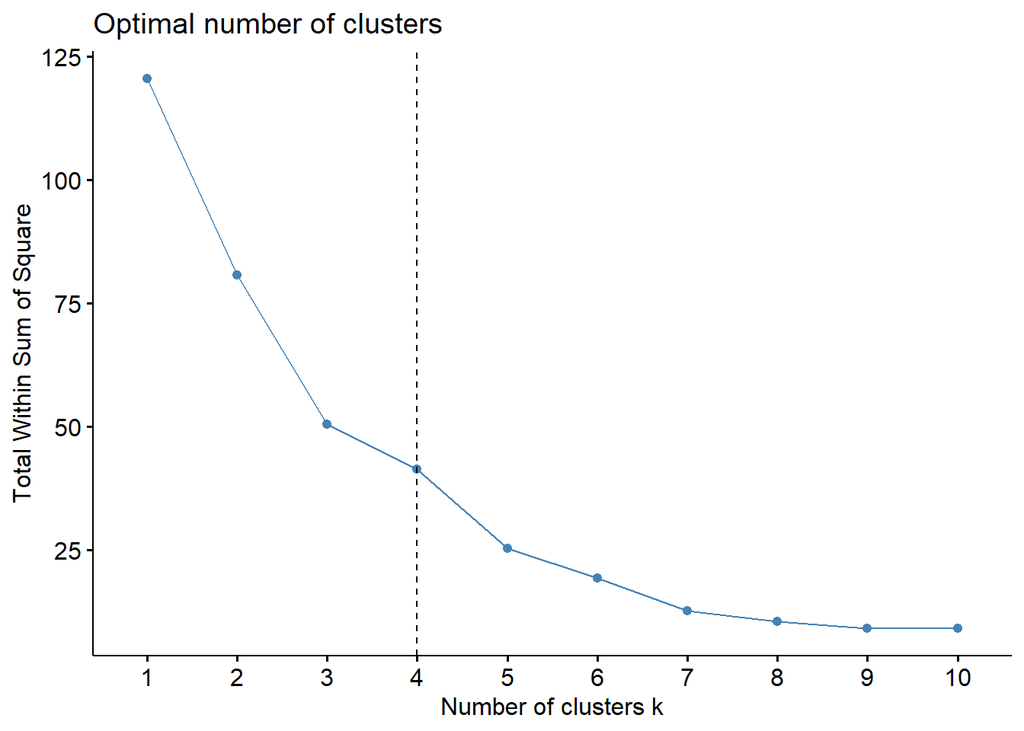

```r
fviz_nbclust(matstd.h1b_pca, kmeans, method = "wss")+geom_vline(xintercept = 4, linetype = 2)
```

##### **Clustering Analysis**

```r
set.seed(123)
kmeans4.h1b_pca <- kmeans(matstd.h1b_pca, 4, nstart = 25)

kmeans4.h1b_pca
```

```
## K-means clustering with 4 clusters of sizes 12, 18, 5, 15
##
## Cluster means:
##           PC1         PC2
## 1  0.08769716 -1.45811701
## 2 -0.37080403  0.05986803
## 3 -2.23402553  1.46993824
## 4  1.11948228  0.60467256
##
## Clustering vector:
##                                CHIEF EXECUTIVE
##                                              4
##                          INFORMATICA DEVELOPER
##                                              2
##                             SOFTWARE DEVELOPER
##                                              4
##                             PROGRAMMER ANALYST
##                                              2
##               SENIOR RESEARCH DATA COORDINATOR
##                                              4
##                         SENIOR PRODUCT MANAGER
##                                              4
##                       USER EXPERIENCE DESIGNER
##                                              2
##                  COMPUTER PROGRAMMER / ANALYST
##                                              2
##                   LEAD DEVELOPMENT COORDINATOR
##                                              2
##                       ASSISTANT VICE PRESIDENT
##                                              3
##          MANAGER, ENTERPRISE SOLUTION DELIVERY
##                                              2
##                          PROJECT MANAGER - III
##                                              4
##                             FUNCTIONAL ANALYST
##                                              1
##                                  MDM DEVELOPER
##                                              2
##                        TB/HIV PROJECT DIRECTOR
##                                              1
```

[output cut: 64 more lines]

```
## SENIOR ASSOCIATE MARKETING STRATEGY & ANALYSIS
##                                              2
##                   TECHNICAL SOLUTIONS ENGINEER
##                                              4
##                           SENIOR CREDIT TRADER
##                                              3
##
## Within cluster sum of squares by cluster:
## [1]  9.881297  7.643450 11.833941  2.970215
##  (between_SS / total_SS =  73.2 %)
##
## Available components:
##
## [1] "cluster"      "centers"      "totss"        "withinss"     "tot.withinss"
## [6] "betweenss"    "size"         "iter"         "ifault"
```

```r
clus1_pca <- matrix(names(kmeans4.h1b_pca$cluster[kmeans4.h1b_pca$cluster == 1]),
                ncol=1, nrow=length(kmeans4.h1b_pca$cluster[kmeans4.h1b_pca$cluster == 1]))
colnames(clus1_pca) <- "Cluster 1"

clus2_pca <- matrix(names(kmeans4.h1b_pca$cluster[kmeans4.h1b_pca$cluster == 2]),
                ncol=1, nrow=length(kmeans4.h1b_pca$cluster[kmeans4.h1b_pca$cluster == 2]))
colnames(clus2_pca) <- "Cluster 2"

clus3_pca <- matrix(names(kmeans4.h1b_pca$cluster[kmeans4.h1b_pca$cluster == 3]),
                ncol=1, nrow=length(kmeans4.h1b_pca$cluster[kmeans4.h1b_pca$cluster == 3]))
colnames(clus3_pca) <- "Cluster 3"

clus4_pca <- matrix(names(kmeans4.h1b_pca$cluster[kmeans4.h1b_pca$cluster == 4]),
                ncol=1, nrow=length(kmeans4.h1b_pca$cluster[kmeans4.h1b_pca$cluster == 4]))
colnames(clus4_pca) <- "Cluster 4"

list(clus1_pca, clus2_pca, clus3_pca, clus4_pca)
```

```
## [[1]]
##       Cluster 1
##  [1,] "FUNCTIONAL ANALYST"
##  [2,] "TB/HIV PROJECT DIRECTOR"
##  [3,] "RESEARCH ASSISTANT PROFESSOR"
##  [4,] "QUALITY CONTROL SUPERVISOR"
##  [5,] "COMMUNICATIONS SPECIALIST"
##  [6,] "DEVICES DESIGN ENGINEER 3"
##  [7,] "PRESCHOOL TEACHER"
##  [8,] "PROCESS ENGINEER"
##  [9,] "PROJECT DEVELOPER"
## [10,] "TUTOR"
## [11,] "AIRCRAFT MAINTENANCE ENGINEER"
## [12,] "TOOLS DEVELOPER"
##
```

[output cut: 46 more lines]

##### **Inference:**

- Based on the results derived from the Elbow Plot, we have created 4 Clusters.
- The output signifies the different clusters that have multiple professions clubbed together based on the first two Principal Components (PCs)

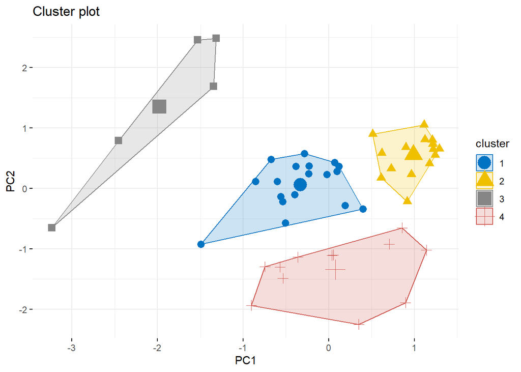

```r
km.res_pca <- kmeans(matstd.h1b_pca, 4, nstart = 25)
# Visualize
fviz_cluster(km.res_pca, data = matstd.h1b_pca,
             ellipse.type = "convex",
             palette = "jco",
             ggtheme = theme_minimal(),
             geom = "point",
             pointsize = 3,
             show.clust.cent = TRUE,
             repel = TRUE)
```

*The names of the job titles have been not displayed to avoid extreme clutter.*